# PredictionAssignment

Christopher Brodowski

May 28, 2017

## Background

The goal of this project is to predict how the test subjects performed a certain exercise using any other number of variables found in a training data set.

Using devices such as Jawbone Up, Nike FuelBand, and Fitbit it is now possible to collect a large amount of data about personal activity relatively inexpensively. These type of devices are part of the quantified self movement - a group of enthusiasts who take measurements about themselves regularly to improve their health, to find patterns in their behavior, or because they are tech geeks. One thing that people regularly do is quantify how much of a particular activity they do, but they rarely quantify how well they do it. In this project, the goal will be to use data from accelerometers on the belt, forearm, arm, and dumbell of 6 participants. They were asked to perform barbell lifts correctly and incorrectly in 5 different ways. More information is available from the website here: http://groupware.les.inf.puc-rio.br/har (see the section on the Weight Lifting Exercise Dataset).

## Load our libraries and set a random seed (used later on)

```r
set.seed(12345)
library(RCurl)
library(data.table)
library(caret)
library(parallel)
library(doParallel)
library(reshape2)
```

```r
library(ggplot2)
```

## Download and Reading Data (Preparing)

### Download the data, if needed

```r
training_url <- url("https://d396qusza40orc.cloudfront.net/predmachlearn/pml-training.csv")
training_file <- "pml_training.csv"
if (!file.exists(training_file)) {
  download.file(training_url, destfile=training_file,
                method="auto")
}
test_url <- url("https://d396qusza40orc.cloudfront.net/predmachlearn/pml-testing.csv")
test_file <- "pml-testing.csv"
if (!file.exists(test_file)) {
  download.file(test_url, destfile=test_file, method="auto")
}
```

### Read the training and testing data into data tables

```r
inDataTraining <- fread(training_file)
TestData <- fread(test_file)
```

## Identification of Prediction Variables

As our predictor (i.e. independent) variables should be our inputs to a model, it is preferable that these variables have valid input. We can either remove invalid/missing inputs from a variety of variables or we can eliminate those with missing data from the start, like the following:

```r
haveMissing <- sapply(TestData, function (x) any(is.na(x) | x == ""))
canPredict <- !haveMissing & grepl("belt|[^(fore)]arm|dumbbell|forearm", names(haveMissing))
predictionPossibilities <- names(haveMissing)[canPredict]
# We are trying to find belt, arm, dumbbell and forearm variables without missing data
varToInclude <- c("classe", predictionPossibilities)
```

## Subset data to get what we want

We now have our desired predictor names. We should now subset the training data set so that we only have the variables we want (i.e., the prediction variables.)

```r
inDataTraining <- inDataTraining[, varToInclude, with=FALSE]
dim(inDataTraining)
```

```
## [1] 19622    53
```

```r
names(inDataTraining)
```

```
##  [1] "classe"               "roll_belt"            "pitch_belt"
##  [4] "yaw_belt"             "total_accel_belt"     "gyros_belt_x"
##  [7] "gyros_belt_y"         "gyros_belt_z"         "accel_belt_x"
## [10] "accel_belt_y"         "accel_belt_z"         "magnet_belt_x"
## [13] "magnet_belt_y"        "magnet_belt_z"        "roll_arm"
## [16] "pitch_arm"            "yaw_arm"              "total_accel_arm"
## [19] "gyros_arm_x"          "gyros_arm_y"          "gyros_arm_z"
## [22] "accel_arm_x"          "accel_arm_y"          "accel_arm_z"
## [25] "magnet_arm_x"         "magnet_arm_y"         "magnet_arm_z"
## [28] "roll_dumbbell"        "pitch_dumbbell"       "yaw_dumbbell"
## [31] "total_accel_dumbbell" "gyros_dumbbell_x"     "gyros_dumbbell_y"
## [34] "gyros_dumbbell_z"     "accel_dumbbell_x"     "accel_dumbbell_y"
## [37] "accel_dumbbell_z"     "magnet_dumbbell_x"    "magnet_dumbbell_y"
## [40] "magnet_dumbbell_z"    "roll_forearm"         "pitch_forearm"
## [43] "yaw_forearm"          "total_accel_forearm"  "gyros_forearm_x"
## [46] "gyros_forearm_y"      "gyros_forearm_z"      "accel_forearm_x"
## [49] "accel_forearm_y"      "accel_forearm_z"      "magnet_forearm_x"
## [52] "magnet_forearm_y"     "magnet_forearm_z"
```

```r
inDataTraining <- inDataTraining[, classe := factor(inDataTraining[, classe])]
inDataTraining[, .N, classe]
```

```
##    classe    N
## 1:      A 5580
## 2:      B 3797
## 3:      C 3422
## 4:      D 3216
## 5:      E 3607
```

We will use 60% of the set for training (therefore, 40% for probing).

```r
# Update: 70% creates a warning; try 65%?
# Update again: 60%
inTrain <- createDataPartition(inDataTraining$classe, p=0.6)
dataTraining <- inDataTraining[inTrain[[1]]]
dataProbed <- inDataTraining[-inTrain[[1]]]
```

### Center and scale

We now need to center and scale the prediction possiblities:

```r
X <- dataTraining[, predictionPossibilities, with=FALSE]
preProc <- preProcess(X)
preProc
```

```
## Created from 11776 samples and 52 variables
##
## Pre-processing:
##   - centered (52)
##   - ignored (0)
##   - scaled (52)
```

### Predict

We have our prediction info set up. Let’s predict based on the preprocessed data:

```r
predictedX <- predict(preProc, X)
dataTrainingCS <- data.table(data.frame(classe = dataTraining[, classe], predictedX))
X <- dataProbed[, predictionPossibilities, with=FALSE]
predictedX <- predict(preProc, X)
dataProbedCS <- data.table(data.frame(classe = dataProbed[, classe], predictedX))
nzv <- nearZeroVar(dataTrainingCS, saveMetrics=TRUE)
if (any(nzv$nzv)) {
  print("We have one of more variables with nearzero variance!  TODO!")
}
```

## Train model

Train and implement the model, if it was not already done (since it takes a bit of time to finish.)

I formed the parallelization bit by following the following links: https://www.r-bloggers.com/how-to-go-parallel-in-r-basics-tips/ https://cran.r-project.org/web/views/HighPerformanceComputing.html

```r
if (!file.exists("trainModelTemplate2.RData")) {
  cl <- makeCluster(detectCores() - 1)
  registerDoParallel(cl)
  ctrl <- trainControl(classProbs=TRUE,
                       savePredictions=TRUE,
                       allowParallel=TRUE)
  # using random forest method
  method <- "rf"
  trainModel <- train(classe ~ ., data=dataTrainingCS, method=method)
  stopCluster(cl)
  trainModel
  hat <- predict(trainModel, dataTrainingCS)
  confusionMatrix(hat, dataTraining[, classe])
  hat <- predict(trainModel, dataProbedCS)
  confusionMatrix(hat, dataProbedCS[, classe])
  varImp(trainModel)
  save(trainModel, file="trainModelTemplate2.RData")
}
```

## Check relationship between a few prediction variables

### Forearm Plot

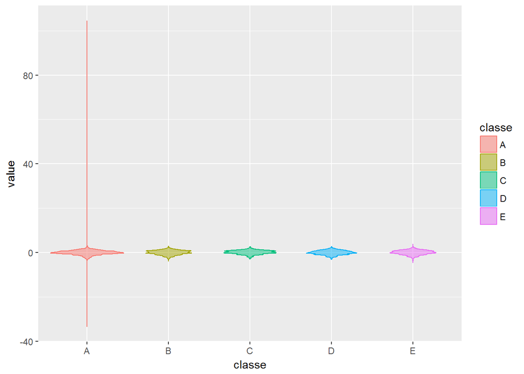

```r
cc <- grep("forearm", names(dataTrainingCS))
cc <- c(cc, which(names(dataTrainingCS) == "classe"))
melted <- melt(dataTrainingCS[,cc,with=FALSE][,rownum:=seq(1,nrow(dataTrainingCS))], id.vars=c("rownum", "classe"))
ggplot(melted, aes(x=classe, y=value)) + geom_violin(aes(color=classe, fill=classe),alpha=0.5)
```

### Belt plot

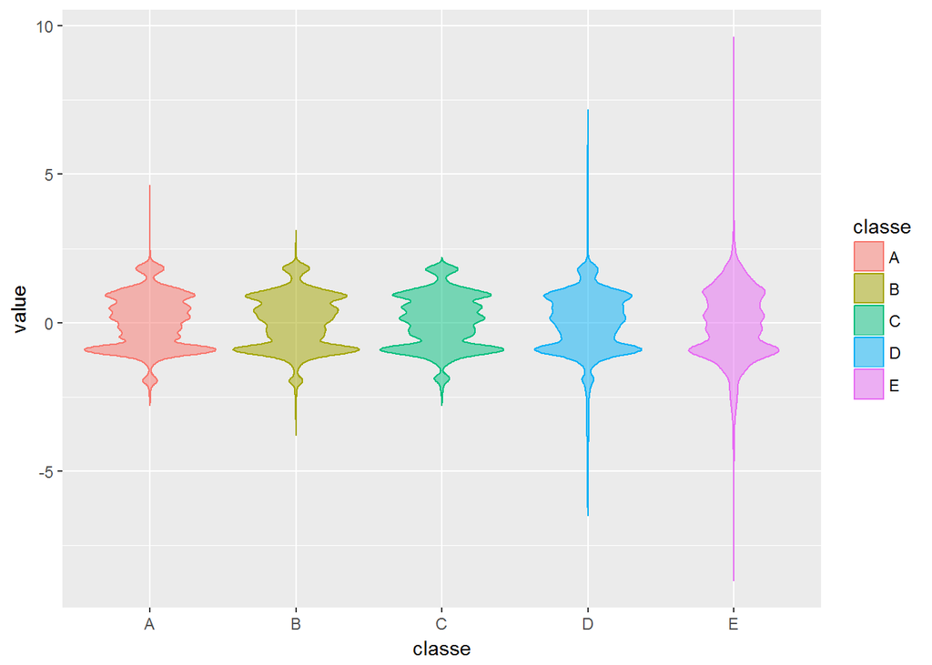

```r
cc <- grep("belt", names(dataTrainingCS))
cc <- c(cc, which(names(dataTrainingCS) == "classe"))
melted <- melt(dataTrainingCS[,cc,with=FALSE][,rownum:=seq(1,nrow(dataTrainingCS))], id.vars=c("rownum", "classe"))
ggplot(melted, aes(x=classe, y=value)) + geom_violin(aes(color=classe, fill=classe),alpha=0.5)
```

## Loading Model and writing data Whether we had to produce the model fresh or not, let’s load it, run the test problems and write the results to files:

```r
load(file="trainModelTemplate2.RData", verbose=TRUE)
```

```
## Loading objects:
##   trainModel
```

```r
TestDataCS <- predict(preProc, TestData[, predictionPossibilities, with=FALSE])
hat <- predict(trainModel, TestDataCS)
TestData <- cbind(hat, TestData)
subset(TestData,
       select=names(TestData)[grep("belt|[^(fore)]arm|dumbbell|forearm",
       names(TestData), invert=TRUE)])
```

```
##     hat V1 user_name raw_timestamp_part_1 raw_timestamp_part_2
##  1:   B  1     pedro           1323095002               868349
##  2:   A  2    jeremy           1322673067               778725
##  3:   B  3    jeremy           1322673075               342967
##  4:   A  4    adelmo           1322832789               560311
##  5:   A  5    eurico           1322489635               814776
##  6:   E  6    jeremy           1322673149               510661
##  7:   D  7    jeremy           1322673128               766645
##  8:   B  8    jeremy           1322673076                54671
##  9:   A  9  carlitos           1323084240               916313
## 10:   A 10   charles           1322837822               384285
## 11:   B 11  carlitos           1323084277                36553
## 12:   C 12    jeremy           1322673101               442731
## 13:   B 13    eurico           1322489661               298656
## 14:   A 14    jeremy           1322673043               178652
```

[output cut: 27 more lines]

```r
outPath <- "C:/Users/cbrodows/PredictionAssignment"
for (iter in 1:length(hat)) {
  pfilename = paste0("problem_id_", iter, ".txt")
  write.table(hat[iter],file=file.path(outPath, pfilename),
              quote=FALSE, row.names=FALSE,
              col.names=FALSE)
}
```